# Who’s Who in Data: Exploring Key Roles

Author

Isaac Beaumont

Published

December 17, 2024

# Why is it so hard to keep defined roles?

Often, companies do not know exactly which role they are seeking to hire. Since the world of data has only gained large-scale attention over the last two decades, many people still don’t fully understand what these roles do or what separates them from one another.

Job postings frequently deviate from the standard definitions because the responsibilities of these roles overlap. In data work, you often need to be a “jack of all trades” while still being a specialist in at least one area.

This post explains what each role traditionally entails and how they differ. This should help those who are curious about the field and those who may be interested in data careers but do not yet know which path to pursue.

# What are the roles?

There are countless job titles in the data world, so it would be unproductive to cover them all. I’ve chosen 10 key roles to focus on. I will explain: who they are and what they generally do.

## Data Scientist

### Who are they?

Data Scientists focus on extracting insights and building predictive models using both structured and unstructured data. They combine expertise in statistics, machine learning, and domain knowledge to solve complex problems and often provide ways to make predictions and automate decision-making.

### What tools do they use?

#### Programming Languages:

- Expected: Python, R, SQL
- Common: Julia, Scala, Rust
- Rare: Javascript, Html (These are used for web and app integration and not analysis)

#### Data Manipulation Libraries:

- Python: NumPy, Pandas, Polars, PySpark
- R: Tidyverse, SparkR

#### Machine Learning

```
-   TensorFlow
-   PyTorch
-   Scikit-Learn
```

#### Visualization Libraries

- Python: Plotly, Matplotlib, Seaborn, Altair
- R: ggplot2, Plotly, Base R

#### Big Data Tools:

- Apache Spark
- Hadoop
- DataBricks

#### Cloud Platforms:

- AWS
- GCP
- Azure

### How do they use these tools?

Programming:

- Python & R: Data cleaning, exploration, visualizing, and modeling.
- SQL: Querying and extracting structured data.

ML Frameworks: Training, testing, and deploying predictive models.

Visualization: Communicating insights via dashboards and charts.

Big Data Tools: Handling large datasets efficiently.

Cloud Platforms: Deployment and scaling of ML workflows.

### Related Roles

Data Analysts: Help refine and interpret findings.

Data Engineers: Provide clean, reliable pipelines.

Machine Learning Engineers: Operationalize and scale models.

Statisticians: Provide deep expertise in statistical methods.

## Data Analyst

### Who are they?

Data Analysts interpret data to provide actionable insights for business decisions. They typically work with structured data to produce reports and dashboards.

### What tools do they use?

- Spreadsheets: Excel, Google Sheets
- BI Tools: Power BI, Tableau, Looker
- SQL
- Visualization: Tableau, Power BI, Matplotlib

### How are the tools used

- Spreadsheets: Quick analysis, pivot tables, lookup functions.
- SQL: Extracting and joining data from relational databases.
- BI Tools: Building interactive dashboards and reports.
- Visualization: Presenting trends and summaries for decision-making

### Related Roles

Data Scientists: Provide cleaned data or exploratory reports for advanced modeling.

Data Engineers: Depend on pipelines and clean datasets.

BI Developers: Overlap exists, but BI Developers are more focused on designing enterprise-level reporting solutions.

## Data Engineer

### Who are they?

Data Engineers build and maintain the infrastructure for data generation, storage, and access. Their primary goal is to ensure data is clean, reliable, and accessible for downstream use.

### What tools do they use?

- Programming Languages: Python, Java, Scala
- Data Pipelines: Apache Airflow, Luigi, Azure Data Factory
- Big Data Tools: Hadoop, Apache Spark
- Cloud Platforms: AWS, Azure, GCP
- ETL Tools: Informatica, Talend

### How are these tools used?

- ETL (Extract, Transform, Load): Convert raw data into structured, reusable formats.
- Pipelines: Automate ingestion and transformation of data.
- Big Data & Cloud: Enable scalability and reliability.

## Database Administrator (DBA)

### Who are they?

DBA’s manage and maintain databases to ensure they are secure, optimized, and backed up. They control access and permissions and handle disaster recovery.

### What tools do they use?

- DBMS: MySQL, PostgreSQL, Oracle, SQL Server
- Backup Tools: RMAN, pgBackRest, SQL Server Agent jobs
- Monitoring Tools: Nagios, SolarWinds, built-in DB tools

### How are these tools used?

- DBMS: Creating, maintaining, and optimizing databases.
- Backup Tools: Ensuring recoverability.
- Monitoring: Tracking performance and resolving issues.

### Related Roles

Data Engineers: Collaborate to ensure pipelines run on healthy databases.

Governance Analysts: Enforce compliance and security standards.

## Machine Learning Engineer

### Who are they?

Specialize in deploying and optimizing machine learning models in production.

### What tools do they use?

Languages: Python, Java

ML Frameworks: TensorFlow, PyTorch

Deployment: Docker, Kubernetes

Cloud: AWS SageMaker, GCP Vertex AI, Azure ML

### How do they use these tools?

Frameworks: Training and tuning models.

Deployment Tools: Serving models as APIs or services.

Cloud: Scaling and managing production ML systems.

### Related Roles

Data Scientists: Translate research models into production-ready systems.

Data Engineers: Ensure pipelines feed real-time or batch data.

AI Researchers: Implement novel algorithms.

## Data Governance Analyst

### Who are they?

They ensure data is managed ethically, securely, and in compliance with regulations (HIPAA, GDPR, CCPA, etc.).

### What tools do they use?

Data Catalog: Collibra, Alation

Compliance: OneTrust, TrustArc

Metadata Management: Apache Atlas

### How do they use these tools?

Data Catalog Tools: To document and manage data assets.

Compliance Tools: To ensure adherence to data privacy laws.

Metadata Management: To track data lineage and quality.

### Related Roles

DBAs: Security and access controls.

Data Engineers: Pipeline compliance.

BI Developers: Data quality in reports.

## Business Intelligence (BI) Developer

### Who are BI Developers?

BI Developers design dashboards and reports for business decision-making.

### What tools do they use?

BI Tools: Tableau, Power BI, Looker

SQL

ETL Tools: Talend, Informatica

### How do they use these tools?

BI Tools: To create dashboards and reports.

SQL: To extract and transform data for visualization.

ETL Tools: To prepare data for analysis.

### Related Roles

Data Analysts: Consumers of dashboards.

Data Engineers: Provide clean, pipelined data.

Data Architects: Collaborate on models.

## Data Architect

### Who are they?

Data Architects design data systems, ensuring they are scalable, efficient, and aligned with business needs.

### What tools do they use?

Modeling: ER/Studio, dbt

Databases: Snowflake, Redshift

Cloud: AWS, Azure, GCP

### How do they use these tools?

Data Modeling Tools: To create schemas and optimize data storage.

Database Systems: To implement scalable architectures.

Cloud Platforms: To manage distributed data systems.

### Related Roles

Data Engineers: Implement designs.

DBAs: Maintain architectures.

BI Developers: Use models for reports.

## Statistician

Who are they?

Statisticians use statistical methods to design experiments, test hypotheses, and analyze data.

### What tools do they use?

Software: R, SAS, Python

Visualization: ggplot2, Matplotlib, Plotly

### How do they use these tools?

R/SAS: For advanced statistical analysis.

Python: For data manipulation and modeling.

Visualization Tools: To present findings effectively.

### Related Roles

Data Scientists: Contribute statistical rigor.

AI Researchers: Assist with model validation.

## AI Researcher

**Who are AI Researchers?**

AI Researchers develop cutting-edge algorithms and models to advance the field of artificial intelligence.

### What tools do they use?

Languages: Python, C++

Frameworks: TensorFlow, PyTorch

Research Tools: Jupyter, LaTeX

### How do they use these tools?

Deep Learning Frameworks: To create and train novel AI models.

Research Tools: To document and publish findings.

### Related Roles

ML Engineers: Translate research into production.

Data Scientists: Collaborate on experimental analysis.

Statisticians: Ensure sound methodology.

Data Engineers: Provide infrastructure for training.

# Conclusion

The graph below shows how these roles connect. Each line represents collaboration or shared responsibilities.

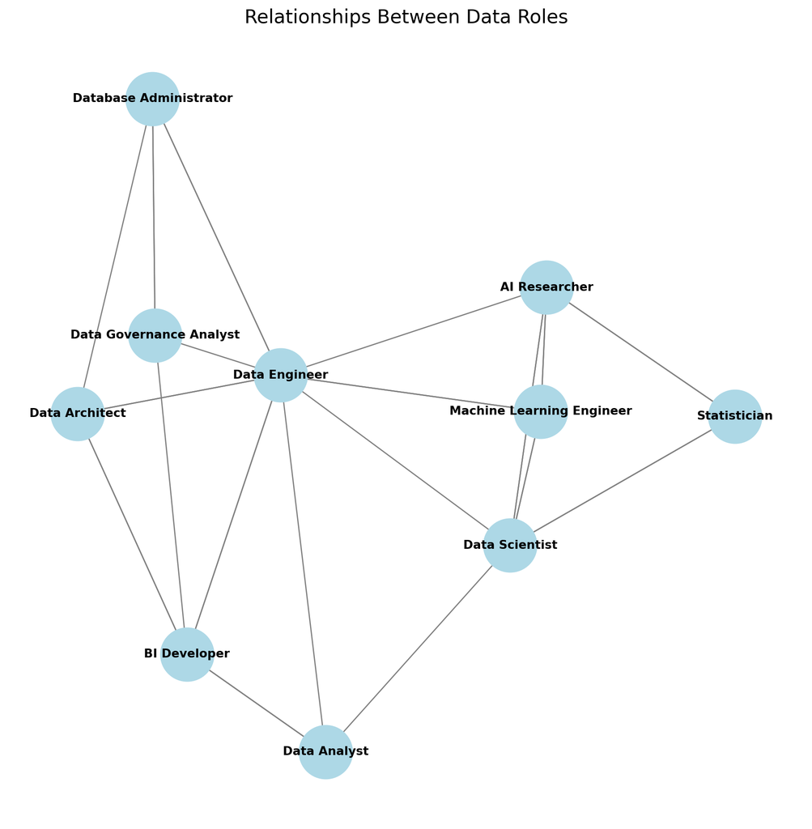

```python
import networkx as nx
import matplotlib.pyplot as plt


roles = [
    "Data Scientist", "Data Analyst", "Data Engineer",
    "Database Administrator", "Machine Learning Engineer",
    "Data Governance Analyst", "BI Developer",
    "Data Architect", "Statistician", "AI Researcher"
]

relationships = [
    ("Data Scientist", "Data Analyst"),
    ("Data Scientist", "Data Engineer"),
    ("Data Scientist", "Machine Learning Engineer"),
    ("Data Scientist", "Statistician"),
    ("Data Scientist", "AI Researcher"),
    ("Data Analyst", "Data Engineer"),
    ("Data Analyst", "BI Developer"),
    ("Data Engineer", "Database Administrator"),
    ("Data Engineer", "Machine Learning Engineer"),
    ("Data Engineer", "BI Developer"),
    ("Data Engineer", "Data Architect"),
    ("Database Administrator", "Data Governance Analyst"),
    ("Database Administrator", "Data Engineer"),
    ("Machine Learning Engineer", "Data Scientist"),
    ("Machine Learning Engineer", "AI Researcher"),
    ("Machine Learning Engineer", "Data Engineer"),
    ("Data Governance Analyst", "Database Administrator"),
    ("Data Governance Analyst", "Data Engineer"),
    ("Data Governance Analyst", "BI Developer"),
    ("BI Developer", "Data Analyst"),
    ("BI Developer", "Data Engineer"),
    ("BI Developer", "Data Architect"),
    ("Data Architect", "Data Engineer"),
    ("Data Architect", "Database Administrator"),
    ("Data Architect", "BI Developer"),
    ("Statistician", "Data Scientist"),
    ("Statistician", "AI Researcher"),
    ("AI Researcher", "Data Scientist"),
    ("AI Researcher", "Machine Learning Engineer"),
    ("AI Researcher", "Statistician"),
    ("AI Researcher", "Data Engineer")
]

G = nx.DiGraph()

G.add_nodes_from(roles)
G.add_edges_from(relationships)

plt.figure(figsize=(12, 12))
pos = nx.spring_layout(G, seed=42)

nx.draw_networkx_nodes(G, pos, node_size=2000, node_color="lightblue")
nx.draw_networkx_edges(G, pos, edge_color="gray", arrowsize=20)
nx.draw_networkx_labels(G, pos, font_size=10, font_color="black", font_weight="bold")

plt.title("Relationships Between Data Roles", fontsize=16)
plt.axis("off")
plt.show()
```

These roles overlap significantly. Success in one often depends on others (e.g., a BI Developer cannot build reports without data pipelines from Data Engineers). While specialization is important, a broad understanding of related roles is invaluable. From my own work I have found, even limited knowledge of all of the disciples has helped me collaborate more effectively with each team.

As stated before: be a jack of all trades, but a specialist in one.